# Bioinformatics Lab 3

Biswas Kumar - Bisku859 Karthikeyan Devarajan - karde799

01/25/2021

# Question 1

## Question 1.1

*Explain all the steps in the script required to obtain the phylogeny and trait data.*  
In step 1, A vector is created with accession numbers with z73494 and AJ53426 to AJ534549.

```r
x <- paste("AJ5345", 26:49, sep = "")
x <- c("Z73494", x)
```

Sequence are obtained using the accession number in GenBank database.

```r
sylvia.seq <- read.GenBank(x)
```

The list contains 25 sequences according to the accession number. “AJ534549” and “AJ534548” has 1041 nucleotides and remaining sequences has 1143 nucleotides.

The alignments are done using cluster.

```r
sylvia.clus <- clustal(sylvia.seq)
```

The alignments can be done by mafft.

```r
#sylvia.maff <- mafft(sylvia.seq)
```

Code to save taxa.sylvia

```r
taxa.sylvia <- attr(sylvia.seq, "species")
names(taxa.sylvia) <- names(sylvia.seq)
taxa.sylvia[1] <- "Sylvia_atricapilla"
taxa.sylvia[24] <- "Sylvia_abyssinica"
```

create a nj distance matrix

```r
f <- function(xx) root(nj(dist.dna(xx, p=TRUE)), "AJ534526")
```

Create a tree based on the distance matrix

```r
tr <- f(sylvia.clus)
nj.est <- tr
```

plot the tree

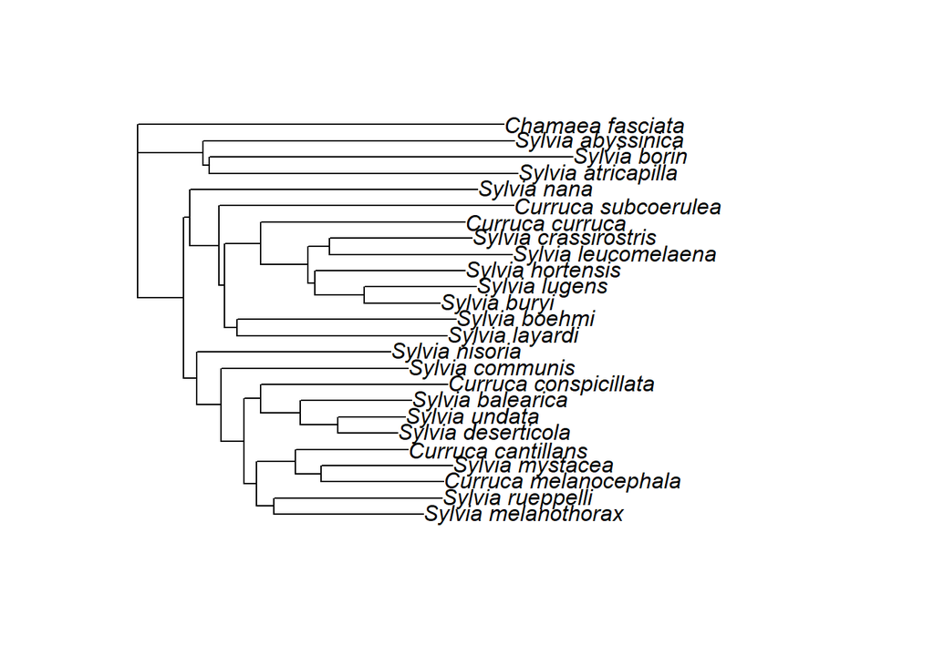

```r
nj.est$tip.label <- taxa.sylvia[tr$tip.label]
write.tree(nj.est, "sylvia_nj_k80.tre")
plot(nj.est)
```

```r
sylvia.eco <- read.table("sylvia_data.txt")
```

Remove the out group species

```r
nj.est <- drop.tip(nj.est, "Chamaea_fasciata")
```

## Question 1.2

*Analyze the discrete (type=discrete) geographical range variable (DF$geo.range) using ape::ace. Consider different models (parameter model). Report on the results and interpret the estimated rates and their standard errors.*

```r
sylvia.eco <- read.table("sylvia_data.txt")
DF <- sylvia.eco[nj.est$tip.label, ]
```

Model - SYM

```r
# SYM
model_1 <- ace(DF$geo.range,phy=nj.est,type = "discrete",model = "SYM")
cat("The log likelihood for model is",model_1$loglik,"\n")
```

```
## The log likelihood for model is -16.97534
```

```r
cat("The AIC value is ",AIC(model_1))
```

```
## The AIC value is  39.95068
```

Model - ER

```r
# ER
model_2 <- ace(DF$geo.range,phy=nj.est,type = "discrete",model = "ER")
cat("The log likelihood for model is",model_2$loglik,"\n")
```

```
## The log likelihood for model is -18.54616
```

```r
cat("The AIC value is ",AIC(model_2))
```

```
## The AIC value is  39.09232
```

The Symmetrical model could be good model since it has highest log likelihood.

# Question 2

Install the ade4 R package. Included with it you will ﬁnd the carnivores dataset, data(carni70).

## Question 2.1

Explore the data set and report what can be found in it. Provide some plots.

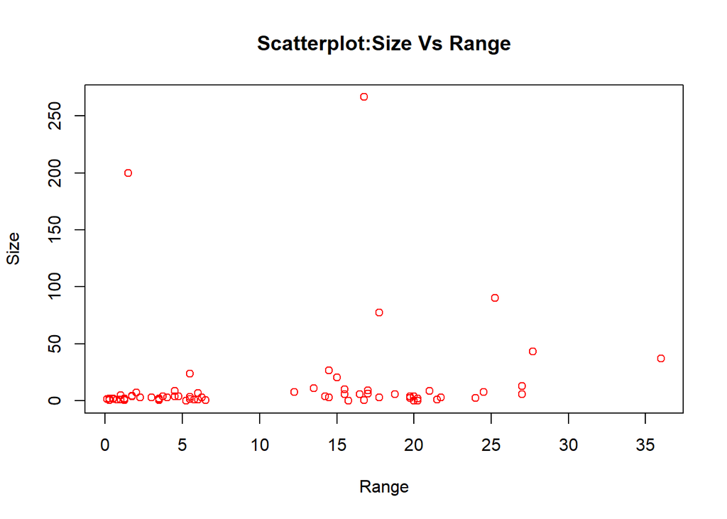

```r
carni<-data(carni70)

#exploring dataset (list of 2 sets)
#head(carni70)

carni_tre<-carni70[1]

carni_tab<-as.data.frame(carni70[2])

# Exploring the dataframe/tab through plots

# scatterplot
plot(carni_tab$tab.range,carni_tab$tab.size,main = "Scatterplot:Size Vs Range",xlab = "Range",ylab="Size",col="red")
```

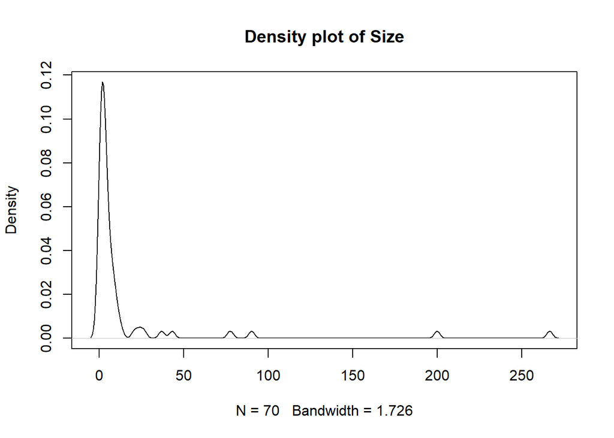

```r
#Density curve
plot(density(carni_tab$tab.size),main="Density plot of Size")
```

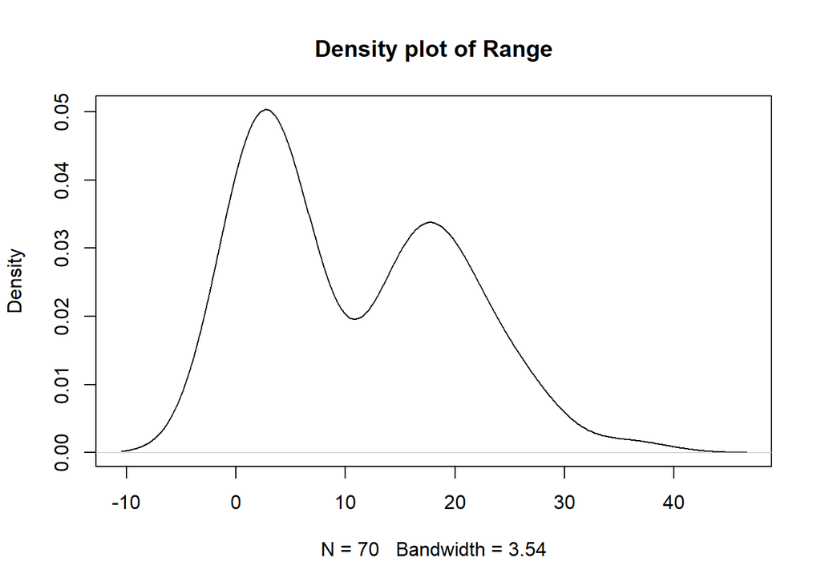

```r
plot(density(carni_tab$tab.range),main="Density plot of Range")
```

```r
scaled_tab<-scale(carni_tab)
print("The Heat map")
```

```
## [1] "The Heat map"
```

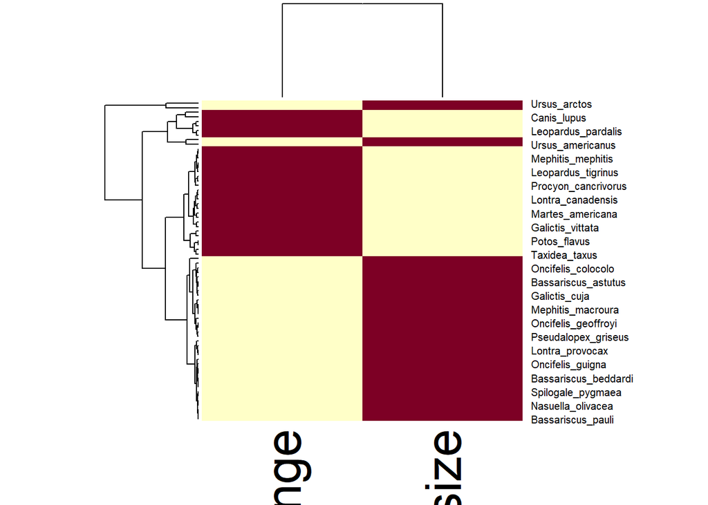

```r
heatmap(scaled_tab)
```

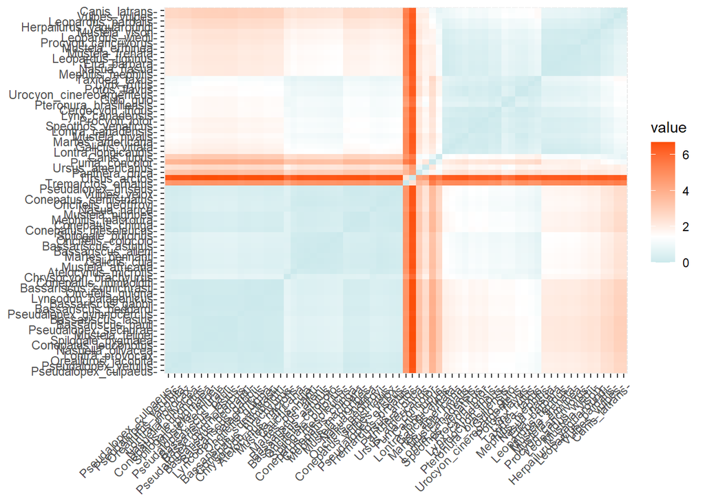

```r
dist_object<-get_dist(scaled_tab)

# Visualizing distance matrix
viz_dist<-fviz_dist(dist_object, gradient = list(low = "#00AFBB", mid = "white", high = "#FC4E07"))

viz_dist
```

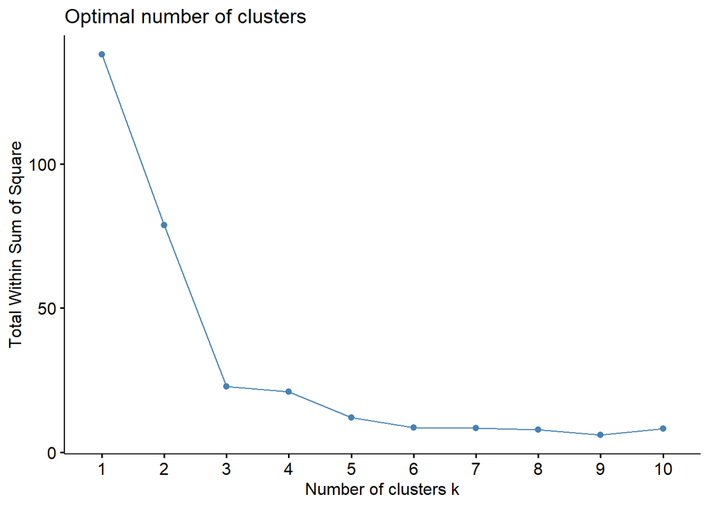

```r
# Determining optimum number of cluster (elbow method), method = "wss" (for total within sum of square)

optimal_cluster_wss<-fviz_nbclust(scaled_tab, kmeans, method = "wss")
optimal_cluster_wss
```

```r
cat("The Optimal number of cluser  with wss method : 3 \n")
```

```
## The Optimal number of cluser  with wss method : 3
```

```r
# K means for 3 clusters
set.seed(123)
k_3 <- kmeans(scaled_tab, 3, nstart = 25)

cluster_grp_no<-table(k_3$cluster)

# visualizing kmeans clusters
carni_grp<-fviz_cluster(k_3, data = scaled_tab,
             ggtheme = theme_minimal(),
             main = "Kmeans Clustering"
             )


#building dataframe with centers and clusters
k_3_centers<-k_3$centers

cluster_no <- c(1: 3)

k_3_center_df <- data.frame(cluster_no, k_3_centers)

library(comprehenr)
No_carnivores<- to_vec(for(i in 1:3) table(k_3$cluster)[[i]])
K_3_cluster_df <- data.frame(cluster_no, No_carnivores)

#frequency of carnivores in each K-3 cluster
K_3_cluster_df
```

```
##   cluster_no No_carnivores
## 1          1            36
## 2          2            32
## 3          3             2
```

Carni70 which is a data set of carnivores has a list of 2 sets (tre and tab). tre is a character sets while tab is a data frame of 70 observations and 2 variables.On further inspection, it could be noticed that tre is basically a phylogenetic tree whereas the tab data set are quantitative traits.

The scatter and density plot was implemented to further understand the distribution of data. Most of the carnivores on scatter plot have lower size with two exceptions. These two exceptions could be the outliers.Also,it could be easily seen that the density chart is heavily skewed/ o weighted towards the left which means that most carnivores have low size and only few are on the extreme.

The unsupervised k means clustering was implemented to check on the the number of clusters using famous elbow method. We got three clusters, out of which maximum data was distributed among first two cluster. It is therefore cluster number 3 with 2 observations can be considered as out liars as most of the data is concentrated between first two clusters

The heat map and distance matrix was also plotted above which depicts two distinct group based on color patterns, that could be easily visualized as two prominent clusters.

Moreover, the hierarchy (dendogram)in the chart could be cut in a way that it gives two prominent cluster and a small cluster which could be termed as outliers.

In short, we found two distinguish clusters in the given data-set with few outliers.

## Question 2.2∗

*Analyze the two traits (size and range) with a number of diﬀerent phylogenetic comparative models. Look at the R packages ape, mvMORPH, mvSLOUCH, ouch and slouch (the last one is NOT on CRAN and can be downloaded from https://github.com/kopperud/slouch). Analyze the data under the following models*  
*1. Both traits evolve as independent Brownian motions.*

```r
#1. Both traits evolve as independent Brownian motions, # BM1 - No covariations
Carni_tree <-read.tree(text = carni70$tre)
Brownian_independent <-mvBM(Carni_tree, carni70$tab,error = NULL, model="BM1",param=list(constraint="diagonal"))
```

```
## row names of the data matrix must match tip names of your phylogeny!
## successful convergence of the optimizer
## a reliable solution has been reached
##
## -- Summary results for constrained rate  BM1 model --
## LogLikelihood:    -589.2373
## AIC:      1186.475
## AICc:     1186.771
## 4 parameters
##
## Estimated rate matrix
## ______________________
##           size    range
## size  73.70338  0.00000
## range  0.00000 13.54519
##
## Estimated root state
## ______________________
##            size    range
## theta: 38.43947 13.78439
```

```r
summary(Brownian_independent)
```

```
## mvMORPH model : BM1  summary
## AIC : 1186.475
## AICc: 1186.771
## Log-Likelihood: -589.2373
## Succesful convergence
## Reliable solution
```

*2. The traits evolve as a correlated Brownian motion.*

```r
#2. Both traits evolve as  correlated Brownian motions
Brownian_correlated <-mvBM(Carni_tree, carni70$tab, model="BM1",param=list(constraint="correlation"))
```

```
##  "shared","variance","correlation" and "proportional" can be used only with BMM model
## row names of the data matrix must match tip names of your phylogeny!
## successful convergence of the optimizer
## a reliable solution has been reached
##
## -- Summary results for multiple rate BM1 model --
## LogLikelihood:    -588.7853
## AIC:      1187.571
## AICc:     1188.018
## 5 parameters
##
## Estimated rate matrix
## ______________________
##            size     range
## size  73.692486  3.578825
## range  3.578825 13.545170
##
## Estimated root state
## ______________________
##            size    range
## theta: 38.43947 13.78439
```

```r
summary(Brownian_correlated)
```

```
## mvMORPH model : BM1  summary
## AIC : 1187.571
## AICc: 1188.018
## Log-Likelihood: -588.7853
## Succesful convergence
## Reliable solution
```

*3. Both traits evolve as independent Ornstein–Uhlenbeck processes.*

```r
#3. Both traits evolve as independent Ornstein–Uhlenbeck processes
Carni_tree_a2o <-ape2ouch(tree = Carni_tree)
summary(Carni_tree_a2o)
```

[output not shown]

```
##   Length    Class     Mode
##        1 ouchtree       S4
```

*4. The traits evolve as a bivariate Ornstein–Uhlenbeck process (use mvMORPH or mvSLOUCH but be careful and check under what assumptions the estimation is done).*

```r
#4. The traits evolve as a bivariate Ornstein–Uhlenbeck process
bivariate_Ornstein <-mvOU(tree=Carni_tree, data=carni70$tab, model="OU1",diagnostic=FALSE, echo=FALSE)
summary(bivariate_Ornstein)
```

```
## mvMORPH model : OU1  summary
## AIC : 1161.213
## AICc: 1162.312
## Log-Likelihood: -572.6063
## Succesful convergence
## Reliable solution
```

*5. size evolves as a Brownian motion and range as an Ornstein–Uhlenbeck process adapting to it (use slouch or mvSLOUCH and be careful about column order).*

```r
rownames(carni70$tab) <- Carni_tree$tip.label
#5. size evolves as a Brownian motion and range as an Ornstein–Uhlenbeck process adapting to it
Brownian_motion <- mvslouchModel(Carni_tree,mData=as.matrix(carni70$tab[,c(2,1)]),kY=1)
```

[output not shown]

```
## Atype is at the default "Invertible" setting. This is a highly inefficient and unrecommended setting. Please look into the possible constraints on A and choose the one best corresponding to the hypothesis on the relationship between the traits.
```

*Compare the ﬁve models and say which one seems to ﬁt better to the data. Summarize (in your own words, NOT just provide the printout, as it can be very long) the output under each model. If for some reason the running time will be prohibitive (more than 12 hours) report how long you ran the code and skip the model. Report on any problems you experienced in your study.*

In order to compare, we will use the metrics to understand the performance of the models.AIC score or AIC highlights the loss of information.The minimum AIC value highlights the minimal loss of information and hence selected as the best model among combinations.AIC is used for smaller samples. On other hand, we look out for higher log-likelihood for better performance of model.In the above results of the models, we see that the AIC value is minimum for model no 4 i.e bivariate Ornstein–Uhlenbeck model. It also have the highest log-likelihood values. It is therefore, model no.4 (bivariate Ornstein–Uhlenbeck model) performs the best among the received outputs.

# Code Appendix

```r
knitr::opts_chunk$set(echo = TRUE)
library(ade4)
library(tidyverse)
library(phyloch)
library(dplyr)
library(stringr)
library(data.table)
library(factoextra)
library(tibble)
library(cluster)
library(mvMORPH)
library(ouch)
library(abind)
library(mvSLOUCH)
library(ape)
x <- paste("AJ5345", 26:49, sep = "")
x <- c("Z73494", x)
sylvia.seq <- read.GenBank(x)
sylvia.clus <- clustal(sylvia.seq)
#sylvia.maff <- mafft(sylvia.seq)
taxa.sylvia <- attr(sylvia.seq, "species")
names(taxa.sylvia) <- names(sylvia.seq)
taxa.sylvia[1] <- "Sylvia_atricapilla"
taxa.sylvia[24] <- "Sylvia_abyssinica"
f <- function(xx) root(nj(dist.dna(xx, p=TRUE)), "AJ534526")
tr <- f(sylvia.clus)
nj.est <- tr
nj.est$tip.label <- taxa.sylvia[tr$tip.label]
write.tree(nj.est, "sylvia_nj_k80.tre")
plot(nj.est)
sylvia.eco <- read.table("sylvia_data.txt")
nj.est <- drop.tip(nj.est, "Chamaea_fasciata")
sylvia.eco <- read.table("sylvia_data.txt")
DF <- sylvia.eco[nj.est$tip.label, ]
# SYM
model_1 <- ace(DF$geo.range,phy=nj.est,type = "discrete",model = "SYM")
cat("The log likelihood for model is",model_1$loglik,"\n")
cat("The AIC value is ",AIC(model_1))
# ER
model_2 <- ace(DF$geo.range,phy=nj.est,type = "discrete",model = "ER")
cat("The log likelihood for model is",model_2$loglik,"\n")
cat("The AIC value is ",AIC(model_2))

carni<-data(carni70)

#exploring dataset (list of 2 sets)
#head(carni70)

carni_tre<-carni70[1]

carni_tab<-as.data.frame(carni70[2])

# Exploring the dataframe/tab through plots

# scatterplot
plot(carni_tab$tab.range,carni_tab$tab.size,main = "Scatterplot:Size Vs Range",xlab = "Range",ylab="Size",col="red")

#Density curve
plot(density(carni_tab$tab.size),main="Density plot of Size")
plot(density(carni_tab$tab.range),main="Density plot of Range")


scaled_tab<-scale(carni_tab)
print("The Heat map")
heatmap(scaled_tab)


dist_object<-get_dist(scaled_tab)

# Visualizing distance matrix
viz_dist<-fviz_dist(dist_object, gradient = list(low = "#00AFBB", mid = "white", high = "#FC4E07"))

viz_dist

# Determining optimum number of cluster (elbow method), method = "wss" (for total within sum of square)

optimal_cluster_wss<-fviz_nbclust(scaled_tab, kmeans, method = "wss")
optimal_cluster_wss
cat("The Optimal number of cluser  with wss method : 3 \n")

# K means for 3 clusters
set.seed(123)
k_3 <- kmeans(scaled_tab, 3, nstart = 25)

cluster_grp_no<-table(k_3$cluster)

# visualizing kmeans clusters
carni_grp<-fviz_cluster(k_3, data = scaled_tab,
             ggtheme = theme_minimal(),
             main = "Kmeans Clustering"
             )


#building dataframe with centers and clusters
k_3_centers<-k_3$centers

cluster_no <- c(1: 3)

k_3_center_df <- data.frame(cluster_no, k_3_centers)

library(comprehenr)
No_carnivores<- to_vec(for(i in 1:3) table(k_3$cluster)[[i]])
K_3_cluster_df <- data.frame(cluster_no, No_carnivores)

#frequency of carnivores in each K-3 cluster
K_3_cluster_df

#1. Both traits evolve as independent Brownian motions, # BM1 - No covariations
Carni_tree <-read.tree(text = carni70$tre)
Brownian_independent <-mvBM(Carni_tree, carni70$tab,error = NULL, model="BM1",param=list(constraint="diagonal"))
summary(Brownian_independent)
#2. Both traits evolve as  correlated Brownian motions
Brownian_correlated <-mvBM(Carni_tree, carni70$tab, model="BM1",param=list(constraint="correlation"))
summary(Brownian_correlated)
#3. Both traits evolve as independent Ornstein–Uhlenbeck processes
Carni_tree_a2o <-ape2ouch(tree = Carni_tree)
summary(Carni_tree_a2o)
#4. The traits evolve as a bivariate Ornstein–Uhlenbeck process
bivariate_Ornstein <-mvOU(tree=Carni_tree, data=carni70$tab, model="OU1",diagnostic=FALSE, echo=FALSE)
summary(bivariate_Ornstein)

rownames(carni70$tab) <- Carni_tree$tip.label
#5. size evolves as a Brownian motion and range as an Ornstein–Uhlenbeck process adapting to it
Brownian_motion <- mvslouchModel(Carni_tree,mData=as.matrix(carni70$tab[,c(2,1)]),kY=1)
```